# Praca domowa 4

Ahmed Abdelkarim, Aleksandra Hernik, Iwona Żochowska

7 listopada 2017

# Wstęp

Celem naszego badania było poznanie odbioru różnych rodzajów wykresów. W tym celu przedstawiliśmy wybrane dane na trzy różne sposoby. Do eksperymentu wykorzystaliśmy dane z [narodowego spisu powszechnego z 2011 roku](https://pl.wikipedia.org/wiki/Narodowy_Spis_Powszechny_2011), przedstawiające deklaracje członków mniejszości narodowych na temat ich przynależności narodowej - jedyna oznacza, że dana osoba identyfikuje się tylko jako członek mniejszości, pierwsza - dana osoba identyfikuje się przede wszystkim jako członek tej mniejszości, druga - dana osoba identyfikuje się przede wszystkim z inną narodowością (prawie zawsze z Polską).

# Wykresy

Stworzyliśmy 3 wykresy, przedstawiające powyższe dane. Wykres treemap przedstawia bezwzględne wartości za pomocą pól, wykres heatmap przedstawia tylko względne wartości - za pomocą koloru, a wykres klockowy przedstawia bezwzględne wartości z niedużą dokładnością za pomocą symboli.

### Treemap

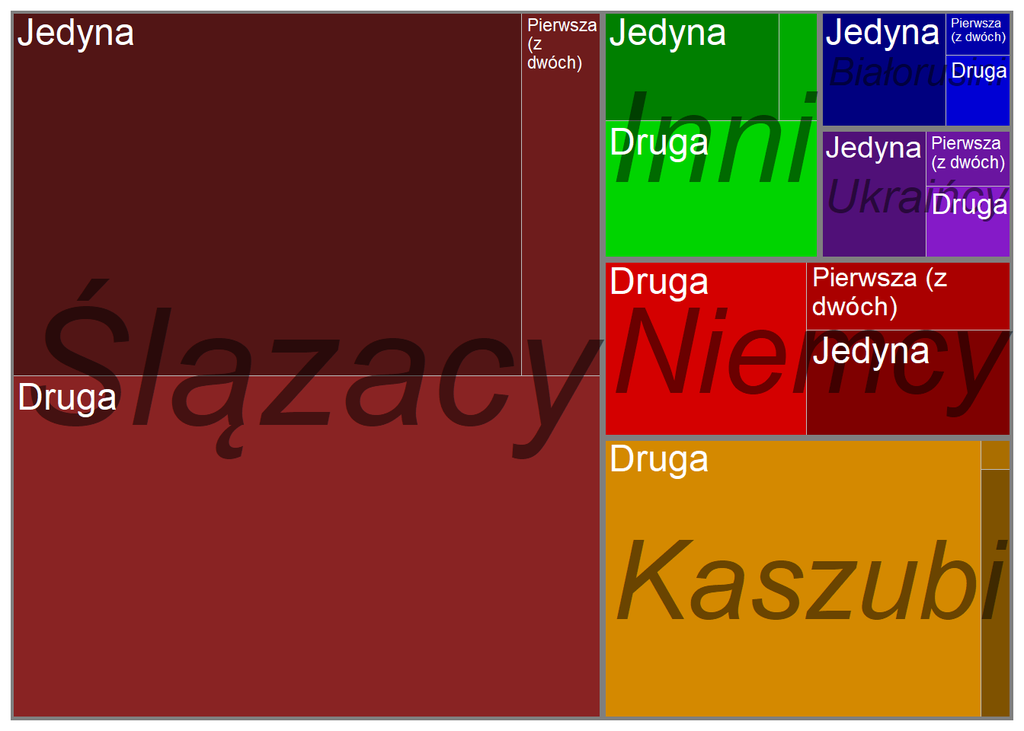

### Heatmap

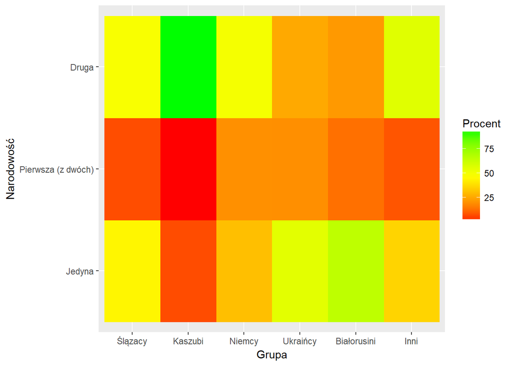

### Blocks

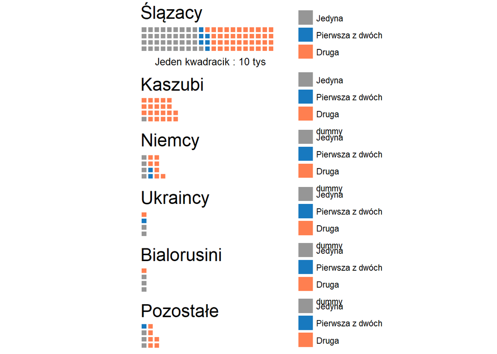

# Ankieta

Dla każdego wykresu stworzyliśmy ankietę, zawierającą następujące pytania:

1. Jakie pierwsze wnioski nasuwają ci się na podstawie tego wykresu?
2. Na ile ten wykres jest czytelny i rzetelnie przedstawia informacje?
3. Jaka część Niemców (w %) identyfikuje się tylko jako Niemcy? (31)
4. Jaka część Kaszubów (w %) identyfikuje się na drugim miejscu jako Kaszubi? (92)
5. Jaka część Białorusinów (w %) identyfikuje się jako Białorusini jako pierwsza lub jedyna narodowość? (78)
6. Członkowie której mniejszości najczęściej identyfikują się tylko jedną narodowością? (Białorusini)
7. Członkowie której mniejszości najczęściej identyfikują się dwiema narodowościami? (Kaszubi)

Każdą z trzech ankiet wysłaliśmy różnym grupom tak, aby nikt nie widział więcej niż jednego wykresu, przedstawiającego te dane. Otrzymaliśmy odpowiednio 11, 12 i 11 odpowiedzi dla ankiet z kolejnymi wykresami.

# Pierwsze wrażenia (pytanie 1)

Powszechny były problemy ze zrozumieniem jakie dane przedstawia wykres. Może to wynikać z niejasnego opisu danych, ale być może dałoby się lepiej wyjaśnić sens danych na samych wykresach.

### Treemap

- Dla większości (8/11 osób) najbardziej rzucającą się w oczy informacją jest duża liczba Ślązaków w Polsce.
- Dwa komentarze dotyczyły nieczytelności.
- Jeden wniosek dotyczył Kaszubów.
- Tylko jeden wniosek ogólny, nie dotyczący konkretnej narodowości: “są różne mniejszości narodowe, około polowa z nich identyfikuje sie z dwoma narodami”.

### Heatmap

- Wnioski były bardziej zróżnicowane.
- Połowa wniosków skupiała się na konkretnej narodowości, głównie Kaszubach, Białorusinach lub obu.
- 3/12 komentarzy krytykowało wykres za nieczytelność, w tym jeden za dobór kolorów.

### Blocks

- 8/11 komentarzy wspomina o Ślązakach.
- Jeden nieprawdziwy wniosek: “Największa mniejszość to kaszubi”.
- 3 inne wnioski: jeden dotyczący Kaszubów (“Kaszubi są Polakami”), jeden Ukraińców i Białorusinów (“W przypadku Ukraińców i Białorusinów jest to większość.”) i jeden ogólny (“Ludzie albo identyfikują się tylko jako mniejszość, albo są przede wszystkim Polakami.”).
- 2 komentarze sugerujące problemy z odczytaniem czegokolwiek z wykresu.

### Wnioski

- Rozmiar i liczba ikon to najbardziej rzucająca się w oczy cecha.

# Ocena czytelności wykresu (pytanie 2)

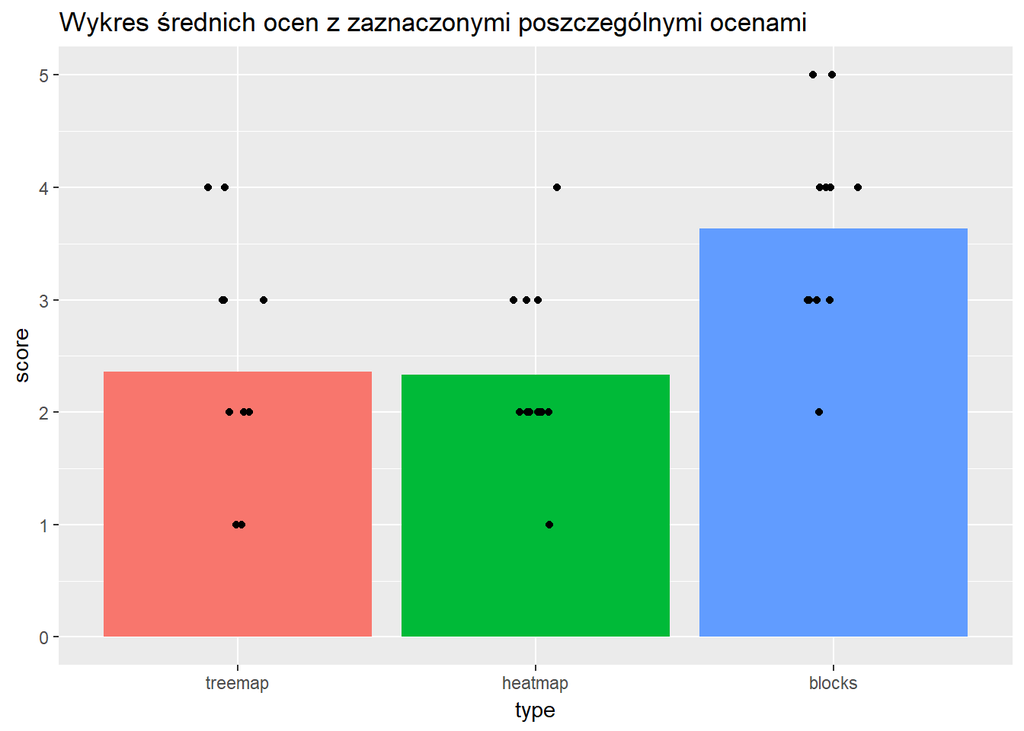

Widać, że wykres klockowy jest zdecydowanym zwycięzcą w ocenie czytelności.

# Poprawność odpowiedzi

### Odczytywanie wartości procentowych (pytania 3-5)

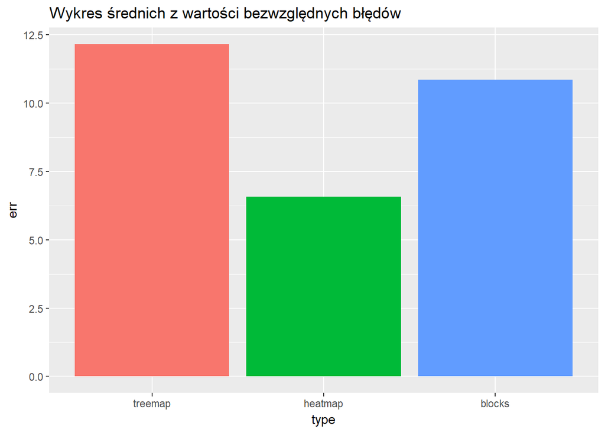

### Wskazanie lidera w danej kategorii (pytania 6-7)

Błąd w odpowiedzi zmierzony został przez odległość wskazanej narodowości od lidera w rankingu danej kategorii - w szczególności wynosił 0 w przypadku poprawnego wskazania i 5 w przypadku odpowiedzi najdalszej od prawdy.

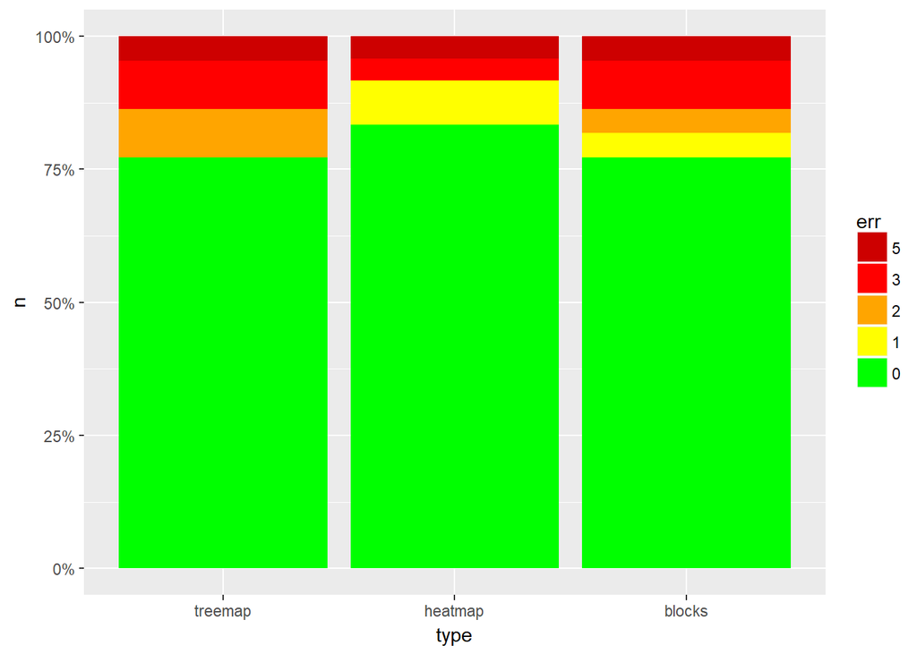

Również przy wskazywaniu lidera heatmapa okazała się najlepsza, choć tutaj przewaga poprawnych odpowiedzi nie jest duża.

# Wnioski

- Sposób prezentacji tych samych danych drastycznie zmienił pierwsze wnioski nasuwające się po zobaczeniu wykresu.
- Deklarowana czytelność wykresu nie musi się wiązać z umiejętnością odczytania danych z wykresu.
- W przypadku wykorzystywania nietypowych rodzajów wykresów należy przyłożyć szczególną wagę do dokładnego opisu - odpowiedniego tytułu, legendy, nazw zmiennych itd.
- Jeżeli zależy nam na zwróceniu uwagi na konkretną cechę danych, może być warto ograniczyć wykres do pokazywania tej cechy. W tym przypadku zawarcie informacji o liczności poszczególnych narodowości odwróciło uwagę odbiorców od drugiego przedstawionego parametru - uznawania danej narodowości za pierwszą, drugą lub jedyną. Być może ułatwiło to też odczyt wartości, przedstawionych na wykresie.
- Wykres klockowy ze względu na swoją specyfikę zaokrąglał dane, co znacząco ograniczało możliwą dokładność odpowiedzi na pytania.